# R Notebook

|  | Freq | % Valid | % Valid Cum. | % Total | % Total Cum. |
| --- | --- | --- | --- | --- | --- |
| Often | 196 | 28.08 | 28.08 | 27.96 | 27.96 |
| Rarely | 98 | 14.04 | 42.12 | 13.98 | 41.94 |
| Routinely | 258 | 36.96 | 79.08 | 36.80 | 78.74 |
| Sometimes | 146 | 20.92 | 100.00 | 20.83 | 99.57 |
|  | 3 |  |  | 0.43 | 100.00 |
| Total | 701 | 100.00 | 100.00 | 100.00 | 100.00 |

$satcurwt Frequencies  
Type: Character

|  | Freq | % Valid | % Valid Cum. | % Total | % Total Cum. |
| --- | --- | --- | --- | --- | --- |
| 1 | 35 | 5.01 | 5.01 | 4.99 | 4.99 |
| 2 | 41 | 5.87 | 10.87 | 5.85 | 10.84 |
| 3 | 78 | 11.16 | 22.03 | 11.13 | 21.97 |
| 4 | 98 | 14.02 | 36.05 | 13.98 | 35.95 |
| 5 | 73 | 10.44 | 46.49 | 10.41 | 46.36 |
| 6 | 36 | 5.15 | 51.65 | 5.14 | 51.50 |
| 7 | 80 | 11.44 | 63.09 | 11.41 | 62.91 |
| 8 | 98 | 14.02 | 77.11 | 13.98 | 76.89 |
| 9 | 99 | 14.16 | 91.27 | 14.12 | 91.01 |
| 10 | 61 | 8.73 | 100.00 | 8.70 | 99.71 |
|  | 2 |  |  | 0.29 | 100.00 |
| Total | 701 | 100.00 | 100.00 | 100.00 | 100.00 |

$satwt18 Frequencies  
Type: Character

|  | Freq | % Valid | % Valid Cum. | % Total | % Total Cum. |
| --- | --- | --- | --- | --- | --- |
| 1 | 12 | 1.72 | 1.72 | 1.71 | 1.71 |
| 2 | 33 | 4.73 | 6.46 | 4.71 | 6.42 |
| 3 | 38 | 5.45 | 11.91 | 5.42 | 11.84 |
| 4 | 60 | 8.61 | 20.52 | 8.56 | 20.40 |
| 5 | 73 | 10.47 | 30.99 | 10.41 | 30.81 |
| 6 | 30 | 4.30 | 35.29 | 4.28 | 35.09 |
| 7 | 72 | 10.33 | 45.62 | 10.27 | 45.36 |
| 8 | 109 | 15.64 | 61.26 | 15.55 | 60.91 |
| 9 | 124 | 17.79 | 79.05 | 17.69 | 78.60 |
| 10 | 146 | 20.95 | 100.00 | 20.83 | 99.43 |
|  | 4 |  |  | 0.57 | 100.00 |
| Total | 701 | 100.00 | 100.00 | 100.00 | 100.00 |

$health Frequencies  
Type: Character

|  | Freq | % Valid | % Valid Cum. | % Total | % Total Cum. |
| --- | --- | --- | --- | --- | --- |
| 1 | 1 | 0.14 | 0.14 | 0.14 | 0.14 |
| 3 | 17 | 2.43 | 2.57 | 2.43 | 2.57 |
| 4 | 21 | 3.00 | 5.57 | 3.00 | 5.56 |
| 5 | 51 | 7.29 | 12.86 | 7.28 | 12.84 |
| 6 | 31 | 4.43 | 17.29 | 4.42 | 17.26 |
| 7 | 117 | 16.71 | 34.00 | 16.69 | 33.95 |
| 8 | 170 | 24.29 | 58.29 | 24.25 | 58.20 |
| 9 | 182 | 26.00 | 84.29 | 25.96 | 84.17 |
| 10 | 110 | 15.71 | 100.00 | 15.69 | 99.86 |
|  | 1 |  |  | 0.14 | 100.00 |
| Total | 701 | 100.00 | 100.00 | 100.00 | 100.00 |

$qolcur Frequencies  
Type: Character

|  | Freq | % Valid | % Valid Cum. | % Total | % Total Cum. |
| --- | --- | --- | --- | --- | --- |
| extremely happy,could not be more pleased | 68 | 9.73 | 9.73 | 9.70 | 9.70 |
| generally dissatisfied, unhappy | 27 | 3.86 | 13.59 | 3.85 | 13.55 |
| generally satisfied, pleased | 238 | 34.05 | 47.64 | 33.95 | 47.50 |
| sometimes fairly satisfied,sometimes fairly unhappy | 113 | 16.17 | 63.81 | 16.12 | 63.62 |
| very dissatisfied, unhappy most of time | 8 | 1.14 | 64.95 | 1.14 | 64.76 |
| very happy most of time | 245 | 35.05 | 100.00 | 34.95 | 99.71 |
|  | 2 |  |  | 0.29 | 100.00 |
| Total | 701 | 100.00 | 100.00 | 100.00 | 100.00 |

$qol18 Frequencies  
Type: Character

|  | Freq | % Valid | % Valid Cum. | % Total | % Total Cum. |
| --- | --- | --- | --- | --- | --- |
| extremely happy, could not be more pleased | 63 | 9.01 | 9.01 | 8.99 | 8.99 |
| generally dissatisfied, unhappy | 39 | 5.58 | 14.59 | 5.56 | 14.55 |
| generally satisfied, pleased | 214 | 30.62 | 45.21 | 30.53 | 45.08 |
| sometimes fairly satisfied,sometimes fairly unhappy | 109 | 15.59 | 60.80 | 15.55 | 60.63 |
| very dissatisfied, unhappy most of time | 15 | 2.15 | 62.95 | 2.14 | 62.77 |
| very happy most of the time | 259 | 37.05 | 100.00 | 36.95 | 99.71 |
|  | 2 |  |  | 0.29 | 100.00 |
| Total | 701 | 100.00 | 100.00 | 100.00 | 100.00 |

$gift Frequencies  
Type: Character

|  | Freq | % Valid | % Valid Cum. | % Total | % Total Cum. |
| --- | --- | --- | --- | --- | --- |
| buy vacation home at place of my choice | 141 | 20.38 | 20.38 | 20.11 | 20.11 |
| donate whole amount to charity of my choice | 33 | 4.77 | 25.14 | 4.71 | 24.82 |
| invest it with brokerage firm | 269 | 38.87 | 64.02 | 38.37 | 63.20 |
| pay off existing mortgage; or buy home outright | 249 | 35.98 | 100.00 | 35.52 | 98.72 |
|  | 9 |  |  | 1.28 | 100.00 |
| Total | 701 | 100.00 | 100.00 | 100.00 | 100.00 |

$winter Frequencies  
Type: Character

|  | Freq | % Valid | % Valid Cum. | % Total | % Total Cum. |
| --- | --- | --- | --- | --- | --- |
| beachfront condo in Hawaii | 294 | 42.18 | 42.18 | 41.94 | 41.94 |
| chalet in Swiss Alps | 145 | 20.80 | 62.98 | 20.68 | 62.62 |
| luxury hotel at Disney World in Florida | 97 | 13.92 | 76.90 | 13.84 | 76.46 |
| ocean cruise through Caribbean Islands | 161 | 23.10 | 100.00 | 22.97 | 99.43 |
|  | 4 |  |  | 0.57 | 100.00 |
| Total | 701 | 100.00 | 100.00 | 100.00 | 100.00 |

$life Frequencies  
Type: Character

|  | Freq | % Valid | % Valid Cum. | % Total | % Total Cum. |
| --- | --- | --- | --- | --- | --- |
| 23 | 2 | 0.30 | 0.30 | 0.29 | 0.29 |
| 30 | 1 | 0.15 | 0.44 | 0.14 | 0.43 |
| 31 | 1 | 0.15 | 0.59 | 0.14 | 0.57 |
| 32 | 1 | 0.15 | 0.74 | 0.14 | 0.71 |
| 40 | 1 | 0.15 | 0.89 | 0.14 | 0.86 |
| 41 | 1 | 0.15 | 1.04 | 0.14 | 1.00 |
| 43 | 1 | 0.15 | 1.18 | 0.14 | 1.14 |
| 45 | 1 | 0.15 | 1.33 | 0.14 | 1.28 |
| 49 | 1 | 0.15 | 1.48 | 0.14 | 1.43 |
| 50 | 2 | 0.30 | 1.78 | 0.29 | 1.71 |
| 51 | 1 | 0.15 | 1.92 | 0.14 | 1.85 |
| 52 | 2 | 0.30 | 2.22 | 0.29 | 2.14 |
| 53 | 6 | 0.89 | 3.11 | 0.86 | 3.00 |
| 54 | 1 | 0.15 | 3.25 | 0.14 | 3.14 |
| 55 | 2 | 0.30 | 3.55 | 0.29 | 3.42 |
| 56 | 7 | 1.04 | 4.59 | 1.00 | 4.42 |
| 57 | 1 | 0.15 | 4.73 | 0.14 | 4.56 |
| 58 | 4 | 0.59 | 5.33 | 0.57 | 5.14 |
| 59 | 3 | 0.44 | 5.77 | 0.43 | 5.56 |
| 60 | 5 | 0.74 | 6.51 | 0.71 | 6.28 |
| 61 | 3 | 0.44 | 6.95 | 0.43 | 6.70 |
| 62 | 2 | 0.30 | 7.25 | 0.29 | 6.99 |
| 63 | 5 | 0.74 | 7.99 | 0.71 | 7.70 |
| 64 | 5 | 0.74 | 8.73 | 0.71 | 8.42 |
| 65 | 2 | 0.30 | 9.02 | 0.29 | 8.70 |
| 66 | 7 | 1.04 | 10.06 | 1.00 | 9.70 |
| 67 | 5 | 0.74 | 10.80 | 0.71 | 10.41 |
| 68 | 10 | 1.48 | 12.28 | 1.43 | 11.84 |
| 69 | 6 | 0.89 | 13.17 | 0.86 | 12.70 |
| 70 | 5 | 0.74 | 13.91 | 0.71 | 13.41 |

[output cut: 51 more lines]

$confid Frequencies  
Type: Character

|  | Freq | % Valid | % Valid Cum. | % Total | % Total Cum. |
| --- | --- | --- | --- | --- | --- |
| 19 | 1 | 0.15 | 0.15 | 0.14 | 0.14 |
| 22 | 1 | 0.15 | 0.29 | 0.14 | 0.29 |
| 23 | 1 | 0.15 | 0.44 | 0.14 | 0.43 |
| 26 | 1 | 0.15 | 0.59 | 0.14 | 0.57 |
| 27 | 1 | 0.15 | 0.73 | 0.14 | 0.71 |
| 28 | 3 | 0.44 | 1.17 | 0.43 | 1.14 |
| 29 | 2 | 0.29 | 1.47 | 0.29 | 1.43 |
| 30 | 1 | 0.15 | 1.62 | 0.14 | 1.57 |
| 32 | 1 | 0.15 | 1.76 | 0.14 | 1.71 |
| 33 | 3 | 0.44 | 2.20 | 0.43 | 2.14 |
| 34 | 3 | 0.44 | 2.64 | 0.43 | 2.57 |
| 35 | 4 | 0.59 | 3.23 | 0.57 | 3.14 |
| 36 | 5 | 0.73 | 3.96 | 0.71 | 3.85 |
| 37 | 3 | 0.44 | 4.41 | 0.43 | 4.28 |
| 38 | 2 | 0.29 | 4.70 | 0.29 | 4.56 |
| 39 | 3 | 0.44 | 5.14 | 0.43 | 4.99 |
| 40 | 2 | 0.29 | 5.43 | 0.29 | 5.28 |
| 41 | 4 | 0.59 | 6.02 | 0.57 | 5.85 |
| 42 | 6 | 0.88 | 6.90 | 0.86 | 6.70 |
| 43 | 7 | 1.03 | 7.93 | 1.00 | 7.70 |
| 44 | 7 | 1.03 | 8.96 | 1.00 | 8.70 |
| 45 | 5 | 0.73 | 9.69 | 0.71 | 9.42 |
| 46 | 8 | 1.17 | 10.87 | 1.14 | 10.56 |
| 47 | 8 | 1.17 | 12.04 | 1.14 | 11.70 |
| 48 | 9 | 1.32 | 13.36 | 1.28 | 12.98 |
| 49 | 13 | 1.91 | 15.27 | 1.85 | 14.84 |
| 50 | 17 | 2.50 | 17.77 | 2.43 | 17.26 |
| 51 | 10 | 1.47 | 19.24 | 1.43 | 18.69 |
| 52 | 19 | 2.79 | 22.03 | 2.71 | 21.40 |
| 53 | 14 | 2.06 | 24.08 | 2.00 | 23.40 |
| 54 | 10 | 1.47 | 25.55 | 1.43 | 24.82 |
| 55 | 12 | 1.76 | 27.31 | 1.71 | 26.53 |
| 56 | 15 | 2.20 | 29.52 | 2.14 | 28.67 |
| 57 | 15 | 2.20 | 31.72 | 2.14 | 30.81 |
| 58 | 16 | 2.35 | 34.07 | 2.28 | 33.10 |
| 59 | 17 | 2.50 | 36.56 | 2.43 | 35.52 |
| 60 | 17 | 2.50 | 39.06 | 2.43 | 37.95 |
| 61 | 18 | 2.64 | 41.70 | 2.57 | 40.51 |
| 62 | 28 | 4.11 | 45.81 | 3.99 | 44.51 |
| 63 | 20 | 2.94 | 48.75 | 2.85 | 47.36 |
| 64 | 21 | 3.08 | 51.84 | 3.00 | 50.36 |
| 65 | 28 | 4.11 | 55.95 | 3.99 | 54.35 |
| 66 | 24 | 3.52 | 59.47 | 3.42 | 57.77 |
| 67 | 26 | 3.82 | 63.29 | 3.71 | 61.48 |
| 68 | 14 | 2.06 | 65.35 | 2.00 | 63.48 |
| 69 | 17 | 2.50 | 67.84 | 2.43 | 65.91 |
| 70 | 20 | 2.94 | 70.78 | 2.85 | 68.76 |
| 71 | 17 | 2.50 | 73.27 | 2.43 | 71.18 |
| 72 | 20 | 2.94 | 76.21 | 2.85 | 74.04 |
| 73 | 19 | 2.79 | 79.00 | 2.71 | 76.75 |
| 74 | 15 | 2.20 | 81.20 | 2.14 | 78.89 |
| 75 | 18 | 2.64 | 83.85 | 2.57 | 81.46 |
| 76 | 16 | 2.35 | 86.20 | 2.28 | 83.74 |
| 77 | 14 | 2.06 | 88.25 | 2.00 | 85.73 |
| 78 | 8 | 1.17 | 89.43 | 1.14 | 86.88 |
| 79 | 11 | 1.62 | 91.04 | 1.57 | 88.45 |
| 80 | 13 | 1.91 | 92.95 | 1.85 | 90.30 |
| 81 | 6 | 0.88 | 93.83 | 0.86 | 91.16 |
| 82 | 11 | 1.62 | 95.45 | 1.57 | 92.72 |
| 83 | 8 | 1.17 | 96.62 | 1.14 | 93.87 |
| 84 | 3 | 0.44 | 97.06 | 0.43 | 94.29 |
| 85 | 3 | 0.44 | 97.50 | 0.43 | 94.72 |
| 86 | 10 | 1.47 | 98.97 | 1.43 | 96.15 |
| 87 | 2 | 0.29 | 99.27 | 0.29 | 96.43 |
| 88 | 2 | 0.29 | 99.56 | 0.29 | 96.72 |
| 91 | 3 | 0.44 | 100.00 | 0.43 | 97.15 |
|  | 20 |  |  | 2.85 | 100.00 |
| Total | 701 | 100.00 | 100.00 | 100.00 | 100.00 |

```r
#load tidyverse
#subset the data with just the factors
data_fac <- data %>% select_if(is.factor)

#now run the apply
apply(data_fac, 2, freq)
```

$gender Frequencies  
Type: Character

|  | Freq | % Valid | % Valid Cum. | % Total | % Total Cum. |
| --- | --- | --- | --- | --- | --- |
| female | 441 | 63.36 | 63.36 | 62.91 | 62.91 |
| male | 255 | 36.64 | 100.00 | 36.38 | 99.29 |
|  | 5 |  |  | 0.71 | 100.00 |
| Total | 701 | 100.00 | 100.00 | 100.00 | 100.00 |

$marital Frequencies  
Type: Character

|  | Freq | % Valid | % Valid Cum. | % Total | % Total Cum. |
| --- | --- | --- | --- | --- | --- |
| Divorced | 35 | 5.09 | 5.09 | 4.99 | 4.99 |
| Living with Significant Other | 44 | 6.40 | 11.48 | 6.28 | 11.27 |
| Married | 346 | 50.29 | 61.77 | 49.36 | 60.63 |
| Never Married | 230 | 33.43 | 95.20 | 32.81 | 93.44 |
| Separated | 13 | 1.89 | 97.09 | 1.85 | 95.29 |
| Widowed | 20 | 2.91 | 100.00 | 2.85 | 98.15 |
|  | 13 |  |  | 1.85 | 100.00 |
| Total | 701 | 100.00 | 100.00 | 100.00 | 100.00 |

$smoke Frequencies  
Type: Character

|  | Freq | % Valid | % Valid Cum. | % Total | % Total Cum. |
| --- | --- | --- | --- | --- | --- |
| Never Smoked | 433 | 62.12 | 62.12 | 61.77 | 61.77 |
| Quit Smoking | 185 | 26.54 | 88.67 | 26.39 | 88.16 |
| Still Smoking | 79 | 11.33 | 100.00 | 11.27 | 99.43 |
|  | 4 |  |  | 0.57 | 100.00 |
| Total | 701 | 100.00 | 100.00 | 100.00 | 100.00 |

$work Frequencies  
Type: Character

|  | Freq | % Valid | % Valid Cum. | % Total | % Total Cum. |
| --- | --- | --- | --- | --- | --- |
| Full-Time | 435 | 62.23 | 62.23 | 62.05 | 62.05 |
| Part-Time | 159 | 22.75 | 84.98 | 22.68 | 84.74 |
| Unemployed | 105 | 15.02 | 100.00 | 14.98 | 99.71 |
|  | 2 |  |  | 0.29 | 100.00 |
| Total | 701 | 100.00 | 100.00 | 100.00 | 100.00 |

$polaff Frequencies  
Type: Character

|  | Freq | % Valid | % Valid Cum. | % Total | % Total Cum. |
| --- | --- | --- | --- | --- | --- |
| Democrat | 225 | 32.51 | 32.51 | 32.10 | 32.10 |
| Independent | 330 | 47.69 | 80.20 | 47.08 | 79.17 |
| Republican | 137 | 19.80 | 100.00 | 19.54 | 98.72 |
|  | 9 |  |  | 1.28 | 100.00 |
| Total | 701 | 100.00 | 100.00 | 100.00 | 100.00 |

$depress Frequencies  
Type: Character

|  | Freq | % Valid | % Valid Cum. | % Total | % Total Cum. |
| --- | --- | --- | --- | --- | --- |
| Often | 48 | 6.86 | 6.86 | 6.85 | 6.85 |
| Rarely | 361 | 51.57 | 58.43 | 51.50 | 58.35 |
| Routinely | 11 | 1.57 | 60.00 | 1.57 | 59.91 |
| Sometimes | 280 | 40.00 | 100.00 | 39.94 | 99.86 |
|  | 1 |  |  | 0.14 | 100.00 |
| Total | 701 | 100.00 | 100.00 | 100.00 | 100.00 |

$exer Frequencies  
Type: Character

|  | Freq | % Valid | % Valid Cum. | % Total | % Total Cum. |
| --- | --- | --- | --- | --- | --- |
| Often | 157 | 22.43 | 22.43 | 22.40 | 22.40 |
| Rarely | 120 | 17.14 | 39.57 | 17.12 | 39.51 |
| Routinely | 154 | 22.00 | 61.57 | 21.97 | 61.48 |
| Sometimes | 269 | 38.43 | 100.00 | 38.37 | 99.86 |
|  | 1 |  |  | 0.14 | 100.00 |
| Total | 701 | 100.00 | 100.00 | 100.00 | 100.00 |

$eat Frequencies  
Type: Character

|  | Freq | % Valid | % Valid Cum. | % Total | % Total Cum. |
| --- | --- | --- | --- | --- | --- |
| Often | 196 | 28.08 | 28.08 | 27.96 | 27.96 |
| Rarely | 98 | 14.04 | 42.12 | 13.98 | 41.94 |
| Routinely | 258 | 36.96 | 79.08 | 36.80 | 78.74 |
| Sometimes | 146 | 20.92 | 100.00 | 20.83 | 99.57 |
|  | 3 |  |  | 0.43 | 100.00 |
| Total | 701 | 100.00 | 100.00 | 100.00 | 100.00 |

$qolcur Frequencies  
Type: Character

|  | Freq | % Valid | % Valid Cum. | % Total | % Total Cum. |
| --- | --- | --- | --- | --- | --- |
| extremely happy,could not be more pleased | 68 | 9.73 | 9.73 | 9.70 | 9.70 |
| generally dissatisfied, unhappy | 27 | 3.86 | 13.59 | 3.85 | 13.55 |
| generally satisfied, pleased | 238 | 34.05 | 47.64 | 33.95 | 47.50 |
| sometimes fairly satisfied,sometimes fairly unhappy | 113 | 16.17 | 63.81 | 16.12 | 63.62 |
| very dissatisfied, unhappy most of time | 8 | 1.14 | 64.95 | 1.14 | 64.76 |
| very happy most of time | 245 | 35.05 | 100.00 | 34.95 | 99.71 |
|  | 2 |  |  | 0.29 | 100.00 |
| Total | 701 | 100.00 | 100.00 | 100.00 | 100.00 |

$qol18 Frequencies  
Type: Character

|  | Freq | % Valid | % Valid Cum. | % Total | % Total Cum. |
| --- | --- | --- | --- | --- | --- |
| extremely happy, could not be more pleased | 63 | 9.01 | 9.01 | 8.99 | 8.99 |
| generally dissatisfied, unhappy | 39 | 5.58 | 14.59 | 5.56 | 14.55 |
| generally satisfied, pleased | 214 | 30.62 | 45.21 | 30.53 | 45.08 |
| sometimes fairly satisfied,sometimes fairly unhappy | 109 | 15.59 | 60.80 | 15.55 | 60.63 |
| very dissatisfied, unhappy most of time | 15 | 2.15 | 62.95 | 2.14 | 62.77 |
| very happy most of the time | 259 | 37.05 | 100.00 | 36.95 | 99.71 |
|  | 2 |  |  | 0.29 | 100.00 |
| Total | 701 | 100.00 | 100.00 | 100.00 | 100.00 |

$gift Frequencies  
Type: Character

|  | Freq | % Valid | % Valid Cum. | % Total | % Total Cum. |
| --- | --- | --- | --- | --- | --- |
| buy vacation home at place of my choice | 141 | 20.38 | 20.38 | 20.11 | 20.11 |
| donate whole amount to charity of my choice | 33 | 4.77 | 25.14 | 4.71 | 24.82 |
| invest it with brokerage firm | 269 | 38.87 | 64.02 | 38.37 | 63.20 |
| pay off existing mortgage; or buy home outright | 249 | 35.98 | 100.00 | 35.52 | 98.72 |
|  | 9 |  |  | 1.28 | 100.00 |
| Total | 701 | 100.00 | 100.00 | 100.00 | 100.00 |

$winter Frequencies  
Type: Character

|  | Freq | % Valid | % Valid Cum. | % Total | % Total Cum. |
| --- | --- | --- | --- | --- | --- |
| beachfront condo in Hawaii | 294 | 42.18 | 42.18 | 41.94 | 41.94 |
| chalet in Swiss Alps | 145 | 20.80 | 62.98 | 20.68 | 62.62 |
| luxury hotel at Disney World in Florida | 97 | 13.92 | 76.90 | 13.84 | 76.46 |
| ocean cruise through Caribbean Islands | 161 | 23.10 | 100.00 | 22.97 | 99.43 |
|  | 4 |  |  | 0.57 | 100.00 |
| Total | 701 | 100.00 | 100.00 | 100.00 | 100.00 |

Plotting

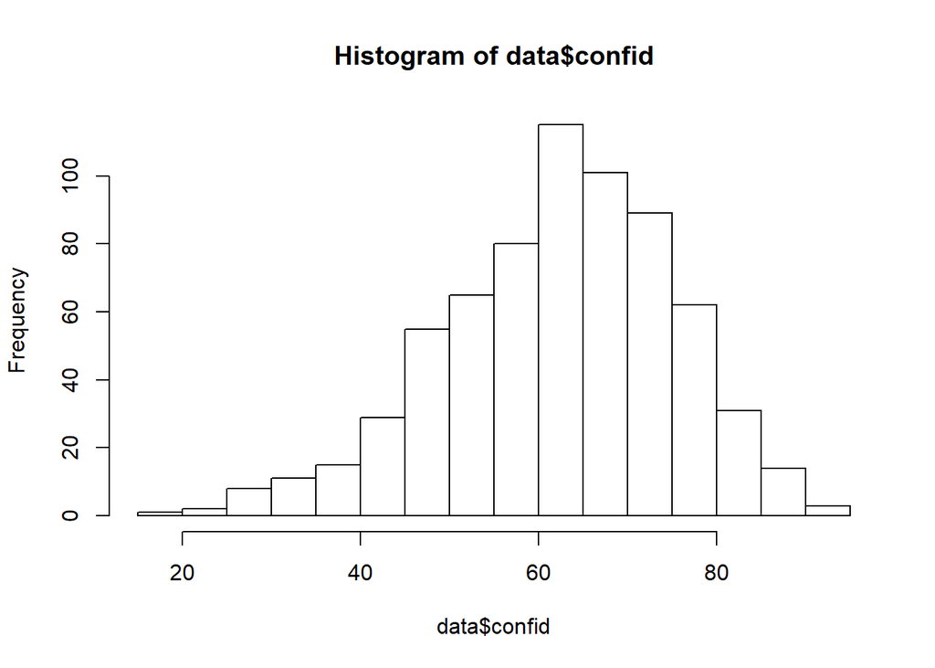

```r
#hitsograms
hist(data$confid,)
```

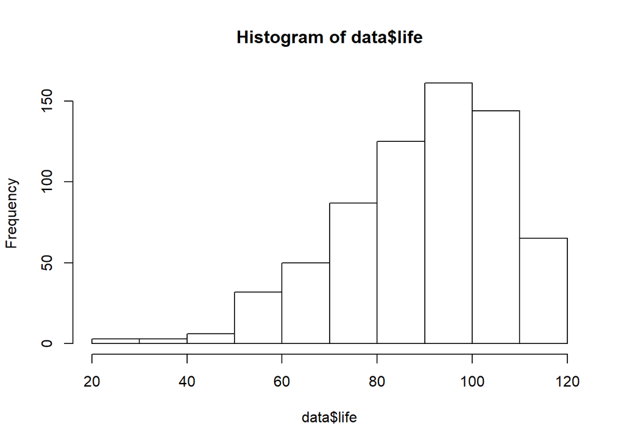

```r
hist(data$life)
```

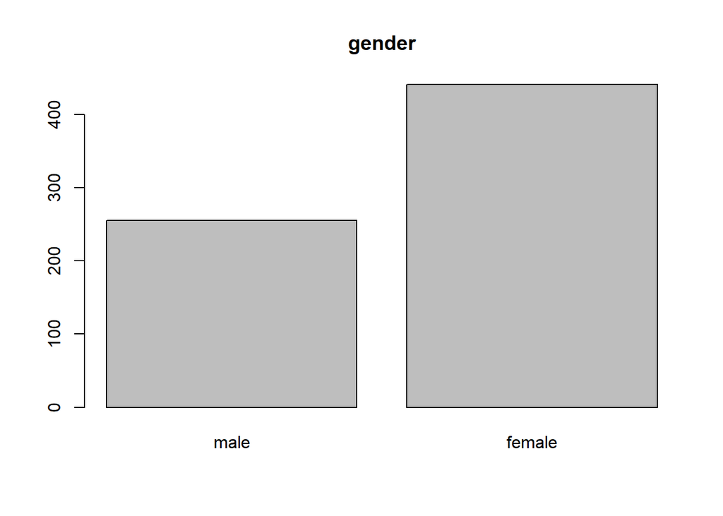

```r
#single plot
plot(data_fac$gender, main = "gender")
```

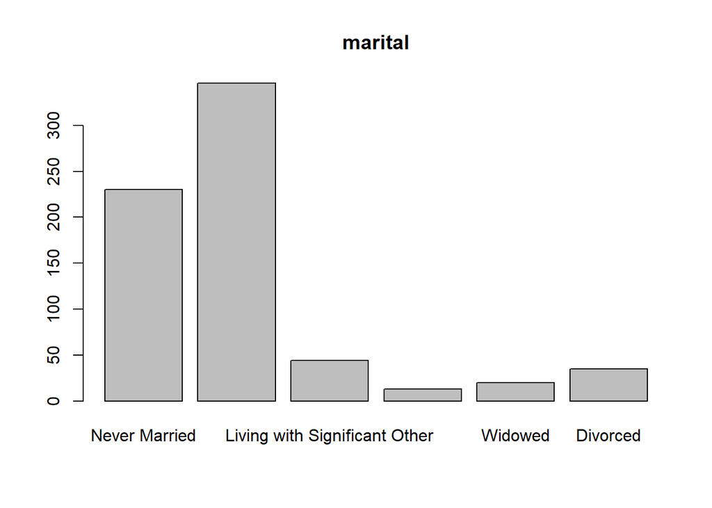

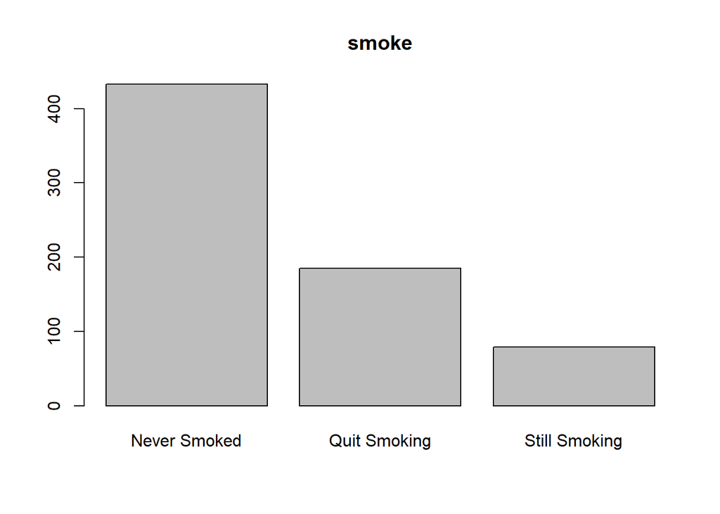

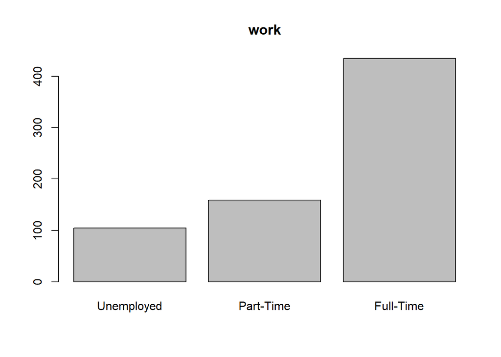

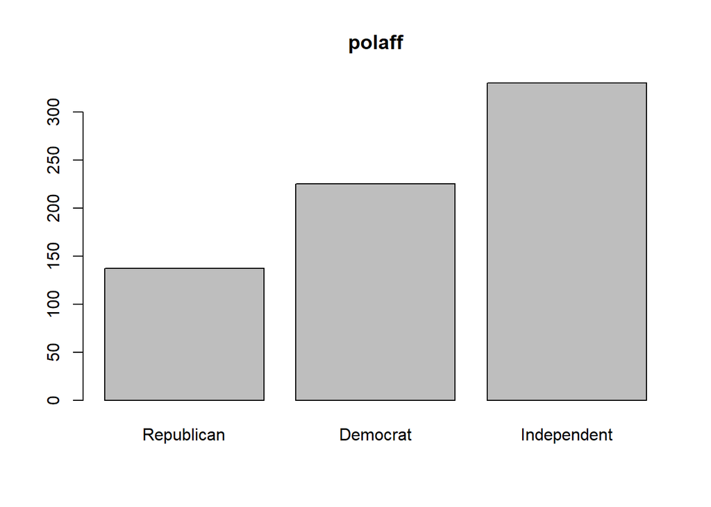

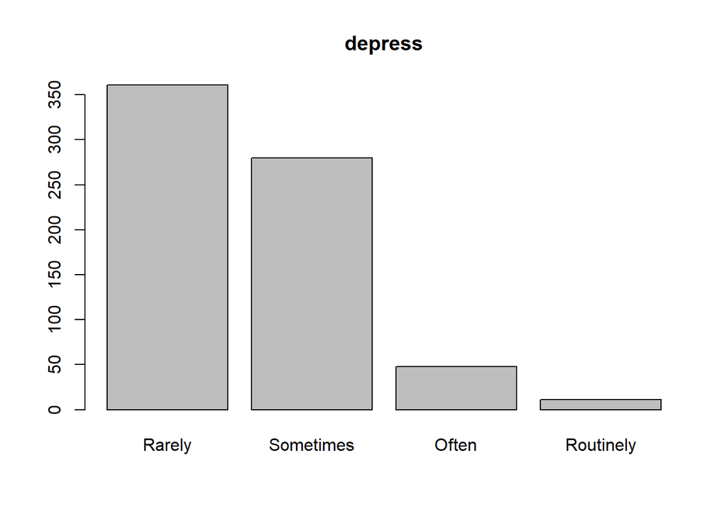

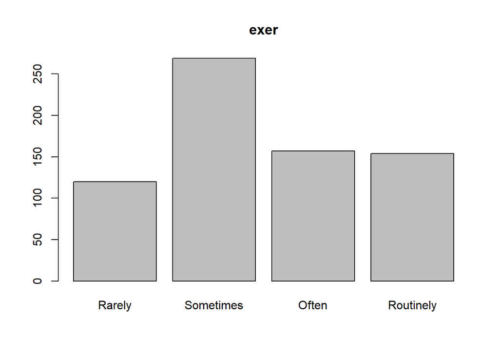

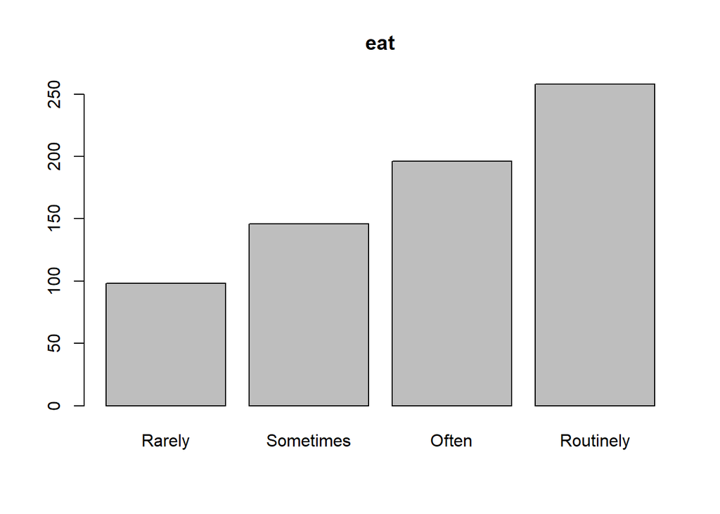

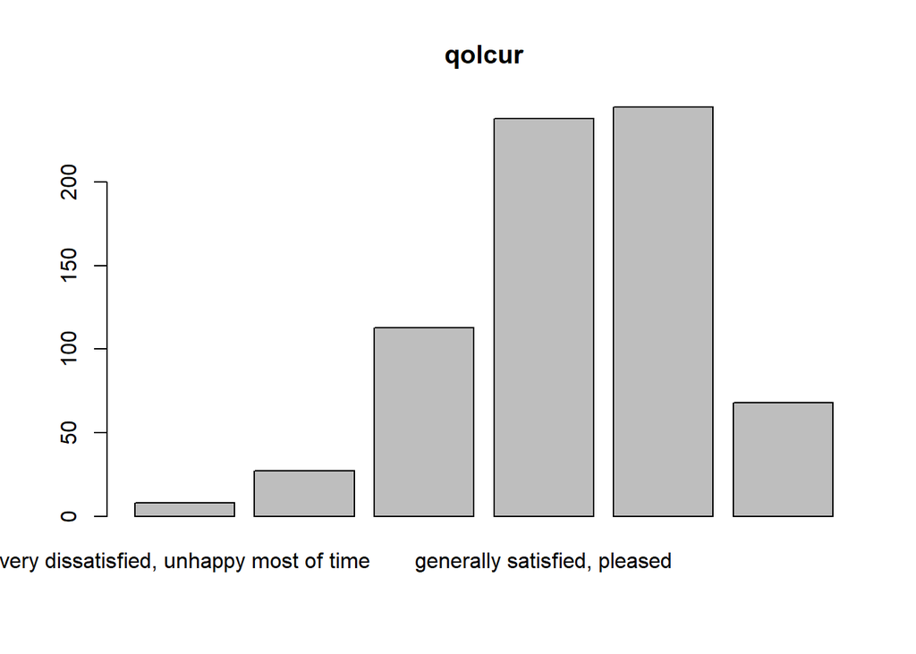

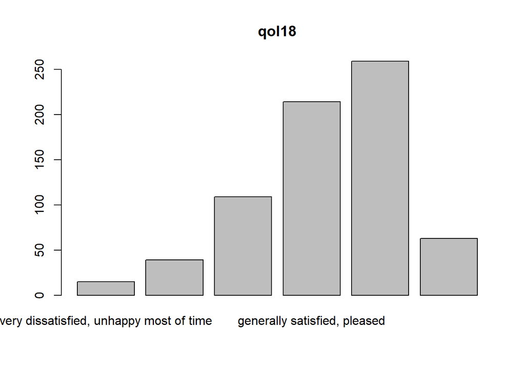

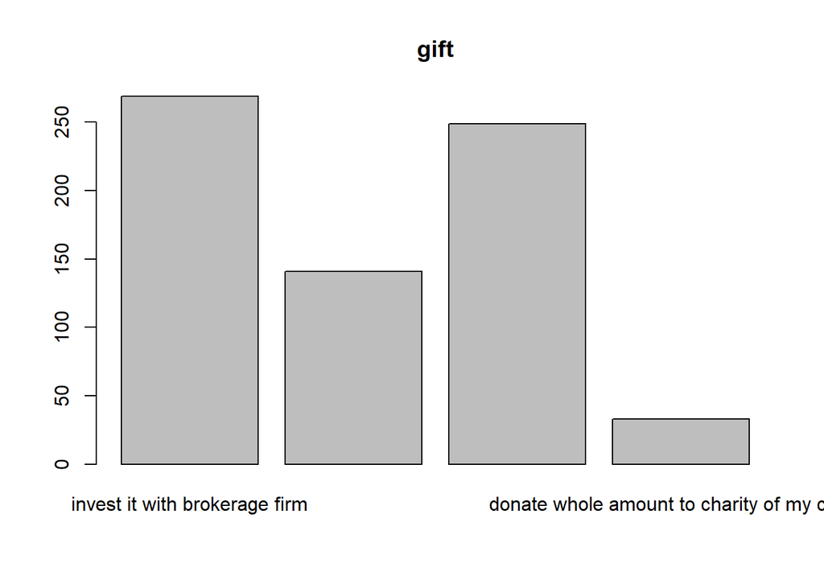

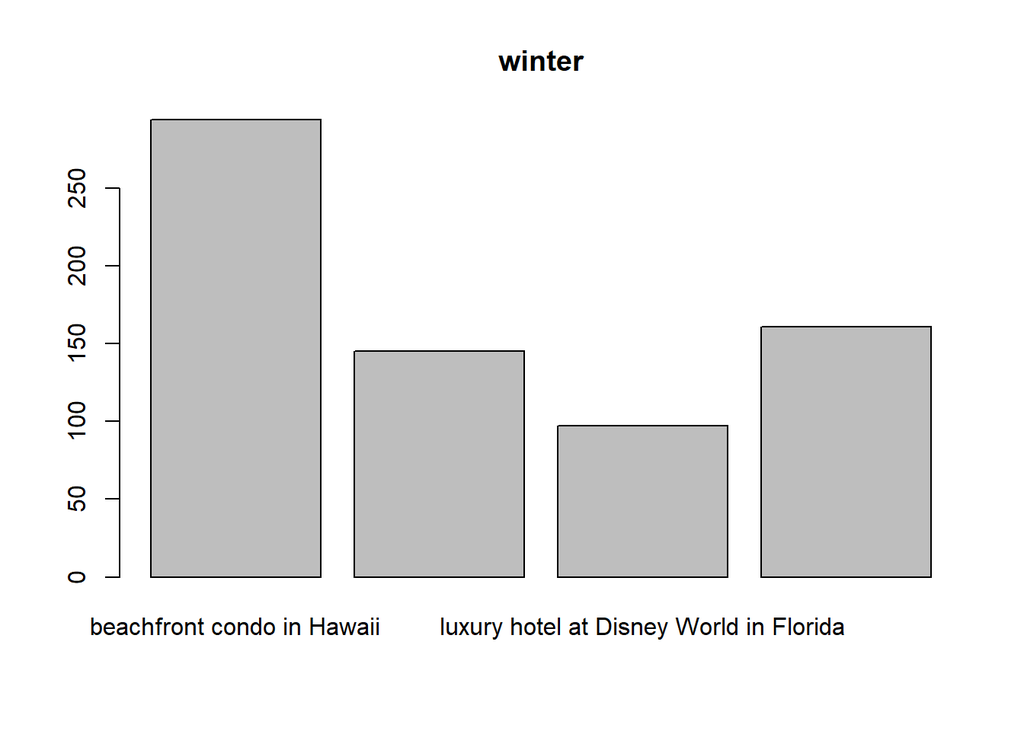

```r
#plot all factors
for (i in colnames(data_fac)){
  plot(data_fac[i], main = i)
}
```

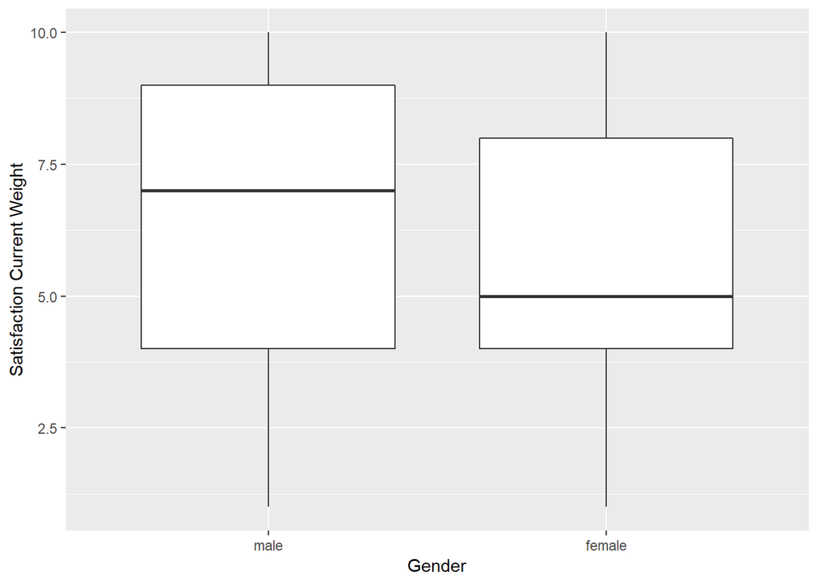

```r
data %>%
  filter(!is.na(gender))%>% #remove blank genders
    ggplot(aes(x=gender, y=satcurwt)) +
      geom_boxplot() +
      xlab("Gender") +
      ylab("Satisfaction Current Weight")
```